# Taller1

JOHN ALEXANDER MARTINEZ Y LEONARDO FABIO HERRERA

2022-03-12

1. Al comparar los caracteres morfométricos de una especie de langostinos de gran importancia económica en Argentina se observaron diferencias de tamaño entre macho y hembra. En la siguiente tabla se presentan los datos (Largo total mm) de las morfometrías de machos y hembras obtenidos en diferentes recolectas (Ruiz & Mendia, 2008).

| *Hembras* |  |  | *Machos* |  |  |
| --- | --- | --- | --- | --- | --- |
| 183.2 | 182.5 | 166.8 | 140.9 | 173.9 | 118.9 |
| 184.1 | 190.0 | 196.3 | 121.7 | 177.4 | 140.0 |
| 183.0 | 178.1 | 183.3 | 173.8 | 154.8 | 192.7 |
| 204.3 | 183.2 | 187.3 | 154.5 | 177.5 | 134.4 |
| 176.5 | 180.4 | 185.8 | 109.2 | 153.4 | 175.0 |
| 179.0 | 184.3 | 189.3 | 150.7 | 138.7 | 169.8 |
| 188.3 | 189.2 | 195.5 | 203.3 | 136.7 | 153.9 |
| 186.8 | 189.1 | 202.4 | 163.0 | 165.3 | 176.7 |
| 202.2 | 203.1 | 210.8 | 137.7 | 126.7 | 150.0 |

1. Haga un histograma con cinco clases y determine la distribución de los datos para cada sexo. Explique acerca de la distribución del tamaño para cada género.
2. Hallar el promedio y la desviación estándar para cada sexo. ¿Qué puede concluir?
3. Halle un intervalo para la media del Largo total por sexo con un nivel de confianza del 97%. Provea la inter-pretación respectiva.
4. Construya un Boxplot por sexo e interprételo.

# Solucion

1. Estas serian las graficas correspondientes.

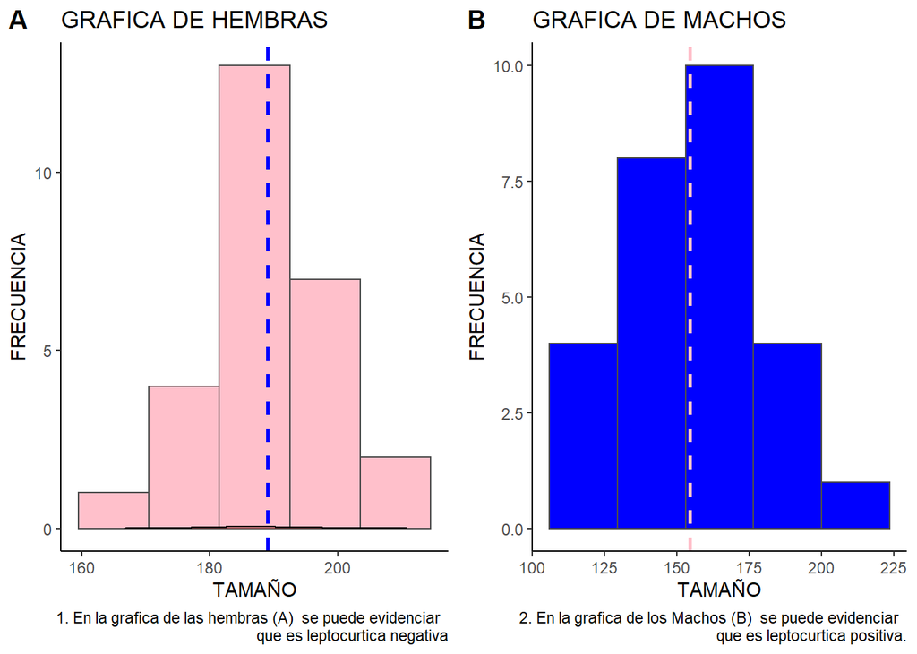

2. El promedio de los tamaños de langostinos hembras es de:189.0667 con una desviacion estandar de 9.83 y el promedio de los tamaños de los langostinos machos es de 154.4667 con una desviacion estandar de 23.064 .

```
## [1] 189.0667
```

```
## [1] 154.4667
```

```
## [1] 9.831151
```

```
## [1] 23.06462
```

c.Intervalo para la media. A partir del resultado obtenido se puede concluir, con un nivel de confianza del 97%, que la altura promedio de las hembras se encuentra entre 184.7230mm y 193.4104. Y para los machos la altura promedio se encuentra entre 144.2760mm y 164.6573mm.

```
## [1] 184.7230 193.4104
## attr(,"conf.level")
## [1] 0.97
```

```
## [1] 144.2760 164.6573
## attr(,"conf.level")
## [1] 0.97
```

4. Por medio de las graficas podemos interpretar que el 50% de las hembras tiene un tamaño mayor a 189 mm, mientras que el 50 % de los machos tiene un tamaño mayor a 154 mm. siendo asi las hembras de mayor tamaño.

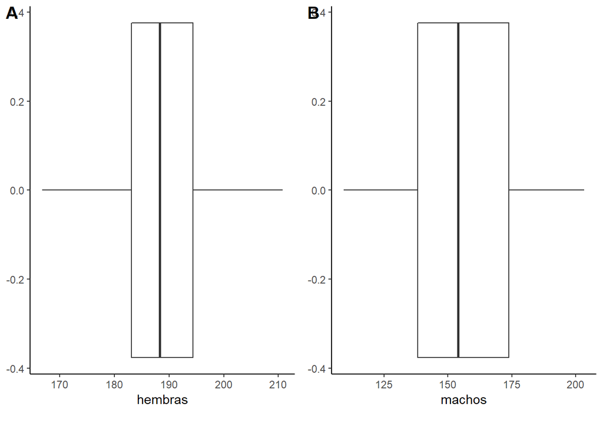

```
##
##  Two-sample Kolmogorov-Smirnov test
##
## data:  hembras and 0.5
## D = 1, p-value = 0.07143
## alternative hypothesis: two-sided
```

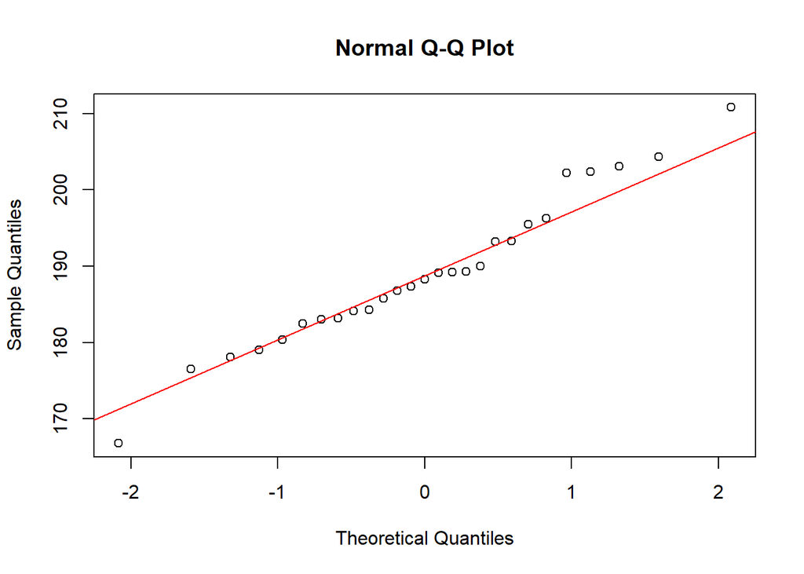

Por lo que podemos apreciar en la graficas, los puntos estan cercanos a la linea recta de ambas graficas y esto nos dice que su distribucion es normal, es decir, que hay normalidad en los datos.

```
##
##  Two-sample Kolmogorov-Smirnov test
##
## data:  machos and 0.5
## D = 1, p-value = 0.07143
## alternative hypothesis: two-sided
```

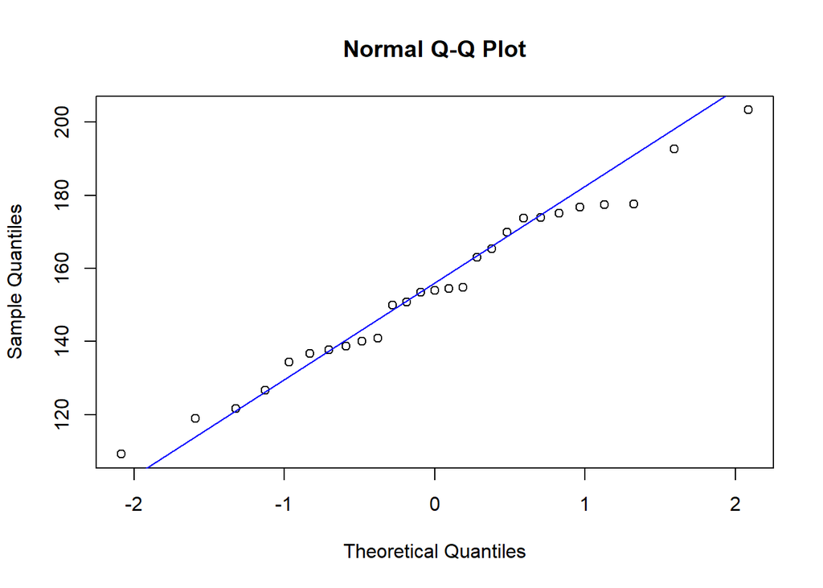

2. En un restaurante de la ciudad se sabe que la probabilidad de que se reciba un billete de $50.000 falso es de 0.015. Si se sabe que en una semana se reciben pagos con 900 billetes de $50.000, halle la probabilidad de que:
1. A lo sumo 25 billetes sean falsos.

*INTERPRETACION :*La probabilidad de que a lo sumo 25 billetes sean falsos es de 0.998.

```
## [1] 0.9985199
```

2. La cantidad de billetes falsos esté entre 20 y 30.

```
## [1] 0.03395327
```

3. Más de 10 sean falsos.

*INTERPRETACION :*La probabilidad de que la cantidad de Billetes falsos sean mas de 10 es de 0.697.

```
## [1] 0.6973098
```

Grafica

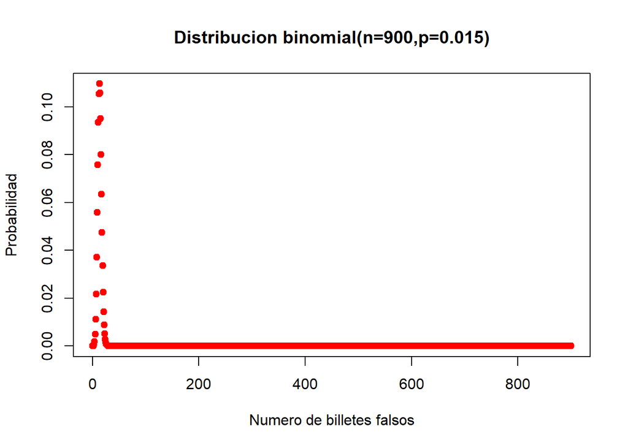

3. Según un estudio del Departamento Nacional de Estadística -DANE-, la vida media para el quinquenio de 2010 a 2015 de los habitantes de Colombia es 76 años, con una varianza de 25. Se pretende hacer un estudio con el objetivo de extrapolar los resultados anteriores a una pequeña ciudad de 100.000 habitantes, considerando que el tiempo de sobrevida es normal.
1. ¿Cuántos de los habitantes de la pequeña ciudad superarán previsiblemente los 92 años?

```
## [1] 0.0006871379
```

2. ¿Cuántos vivirán menos de 55 años o más de 75 años?

```
## [1] 1.334575e-05
```

```
## [1] 0.5792597
```

```
## [1] 0.5792731
```

Grafica

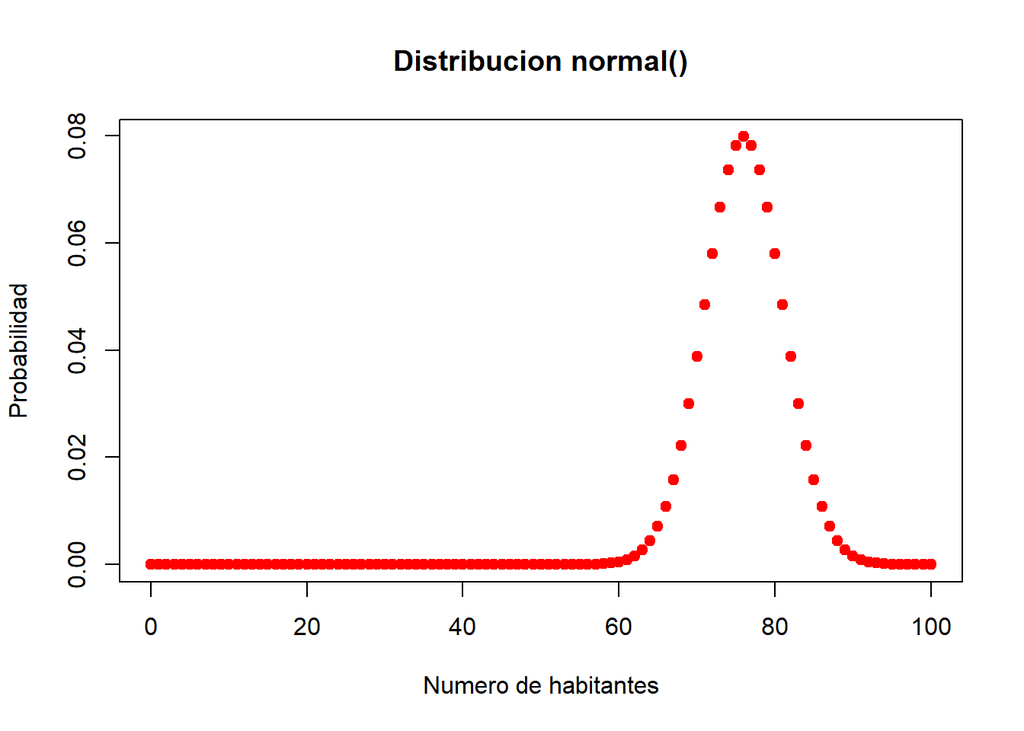

[figure not shown]